# MA331-Coursework

Text analytics of the TED talks by LOUIE SCHWARTZBERG and ELON MUSK

2111321-Oluwasola-Mustapha

# Introduction

In this Report I will be doing a presentation, comparison and sentiment analysis of the most frequently used words of Two Speakers at the “TED TALKS”.The first speaker being Louie Schwartzberg (Talks about “The Hidden Beauty of Pollination” which was delivered in the year 2011 and “Hidden Miracles of The Natural World” delivered in the year 2014) while the second speaker being Elon Musk (Talks about ” The future we’re building –and boring” a talk interview delivered in the year 2017 and also “The Mind Behind Tesla, SpaceX, SolarCity…” another talk interview which was delivered in the year 2013). I will be making use of individual plots and comparative graphs to show the similiarities and differences between both speakers most commonly used words as well as using the ‘nrc’ sentiment analysis package to determine the emotions and sentiments.

# Methods

For this report i will be showing Individual Plots (Graphs) of the most commonly used words for the speakers and also compare both speakers in a graphical representation. The methods include:

1. Tokenization
2. Removal of Stop Words
3. Top Words Identification and Visualization for Individual Speakers
4. Comparision and Visualization of Top Words for Both Speakers
5. Sentiment Analysis

### Tokenization

The process of breaking down sentences into singular texts is known as *Tokenization*. I have done the process of breaking down every sentences into single words per row

### Removal of Stop Words

Stop words are basically words such as “of”, “the”, “to”, “is” which are not necessarily useful in text analysis. I further added words such as “ca”, “em”, “applause”, “yeah” and “laughter” which appeared the most in Elon Musk talks and they are simply the initials of the Host and Speaker names as well as gestures from the audience. The (anti_join) function helps us to get rid of all of these stopwords.

```
## # A tibble: 3,379 × 5
##    talk_id headline                         speaker              views word
##      <dbl> <chr>                            <chr>                <dbl> <chr>
##  1    1140 The hidden beauty of pollination Louie Schwartzberg 1986850 ted
##  2    1140 The hidden beauty of pollination Louie Schwartzberg 1986850 presenta…
##  3    1140 The hidden beauty of pollination Louie Schwartzberg 1986850 head
##  4    1140 The hidden beauty of pollination Louie Schwartzberg 1986850 amazing
##  5    1140 The hidden beauty of pollination Louie Schwartzberg 1986850 concepts
##  6    1140 The hidden beauty of pollination Louie Schwartzberg 1986850 feet
##  7    1140 The hidden beauty of pollination Louie Schwartzberg 1986850 life
##  8    1140 The hidden beauty of pollination Louie Schwartzberg 1986850 forget
##  9    1140 The hidden beauty of pollination Louie Schwartzberg 1986850 pollinat…
## 10    1140 The hidden beauty of pollination Louie Schwartzberg 1986850 granted
## # … with 3,369 more rows
```

## Visualizing the Top Words

### Louie’s Top Words

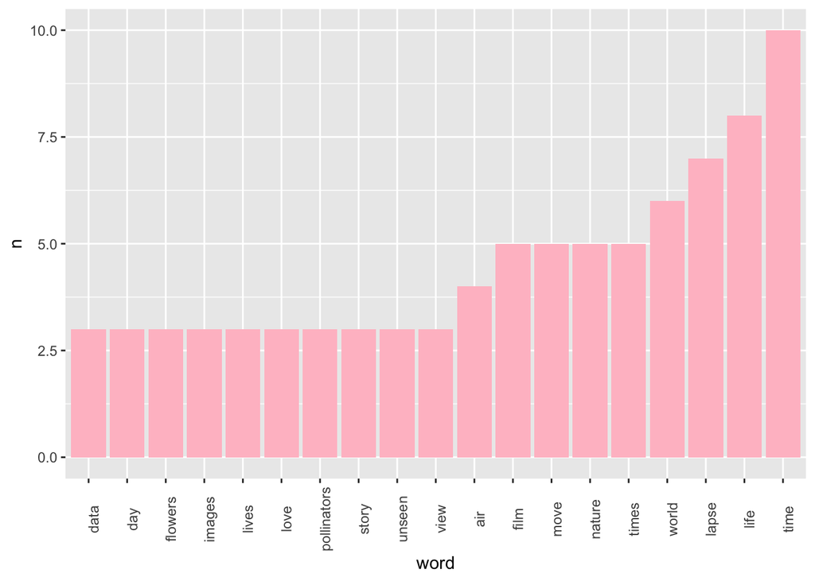

### Elon’s Top Words

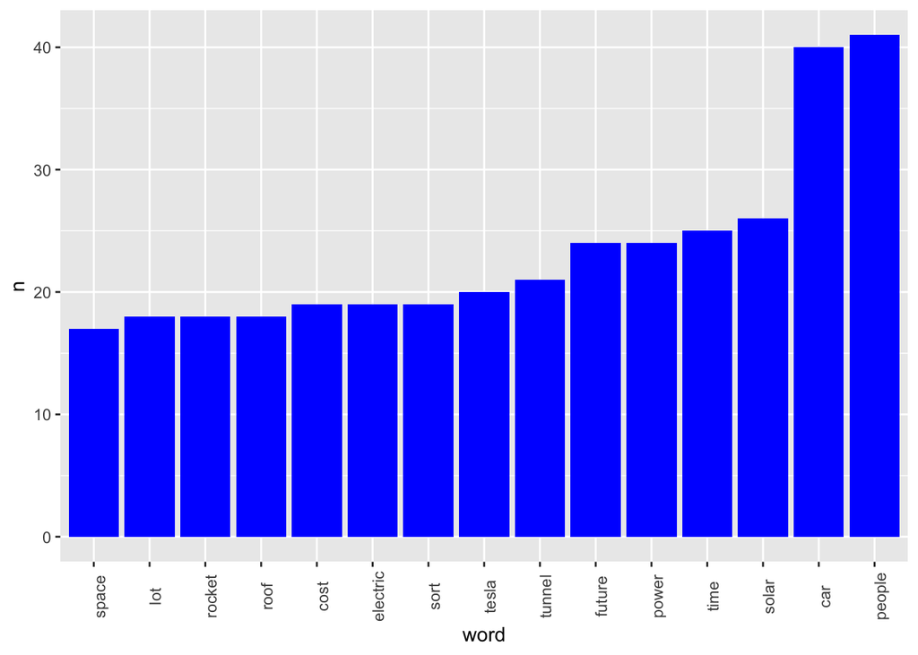

### A Comparision of both Speakers Top words

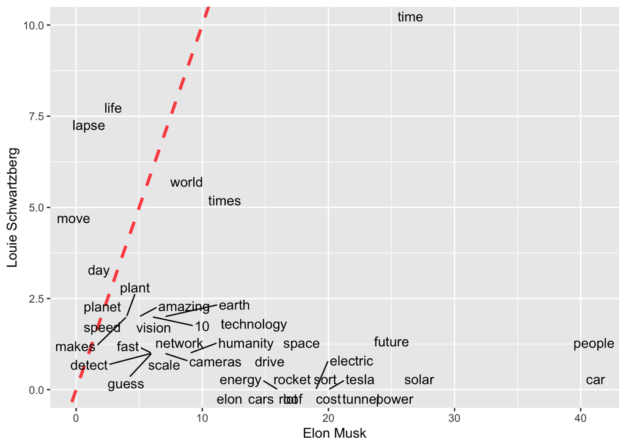

## Sentiments Analysis

First we try to assign the **nrc** sentiments to our speakers words in *tidy_talks_nonstop* by using the *inner_join* function. Then we present the sentiments per speaker and show the counts in a wide format where each sentiments count are shown in individual speaker columns.

```
## # A tibble: 1,518 × 6
##    talk_id headline                         speaker        views word  sentiment
##      <dbl> <chr>                            <chr>          <dbl> <chr> <chr>
##  1    1140 The hidden beauty of pollination Louie Schwar… 1.99e6 forg… negative
##  2    1140 The hidden beauty of pollination Louie Schwar… 1.99e6 gran… positive
##  3    1140 The hidden beauty of pollination Louie Schwar… 1.99e6 time  anticipa…
##  4    1140 The hidden beauty of pollination Louie Schwar… 1.99e6 lapse negative
##  5    1140 The hidden beauty of pollination Louie Schwar… 1.99e6 watch anticipa…
##  6    1140 The hidden beauty of pollination Louie Schwar… 1.99e6 watch fear
##  7    1140 The hidden beauty of pollination Louie Schwar… 1.99e6 dance joy
##  8    1140 The hidden beauty of pollination Louie Schwar… 1.99e6 dance positive
##  9    1140 The hidden beauty of pollination Louie Schwar… 1.99e6 dance trust
## 10    1140 The hidden beauty of pollination Louie Schwar… 1.99e6 tired negative
## # … with 1,508 more rows
```

Now we calculate the Odds ratios and the log Odd ratios of the sentiments for both speakers and add it to our sentiments table then a Function to compute confidence interval for log(OR) and Display Plots of Sentiments against Speaker

```
## # A tibble: 10 × 7
##    sentiment    `Elon Musk` `Louie Schwartzberg`    OR  log_OR CI.lower CI.upper
##    <fct>              <int>                <int> <dbl>   <dbl>    <dbl>    <dbl>
##  1 disgust               24                    9 0.420 -0.868   -0.0875  -1.65
##  2 negative             116                   28 0.637 -0.452   -0.0106  -0.893
##  3 fear                  72                   16 0.711 -0.342    0.221   -0.904
##  4 sadness               41                    9 0.727 -0.319    0.418   -1.06
##  5 anticipation         170                   33 0.806 -0.215    0.190   -0.620
##  6 joy                  147                   23 1.04   0.0352   0.501   -0.431
##  7 anger                 68                    9 1.23   0.208    0.919   -0.502
##  8 positive             398                   54 1.27   0.241    0.572   -0.0895
##  9 trust                199                   23 1.47   0.384    0.842   -0.0746
## 10 surprise              72                    7 1.70   0.530    1.32    -0.260
```

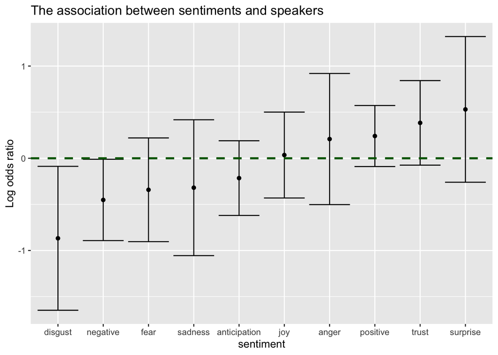

[figure not shown]

# Discussion

The sentiments analysis shows us that there were more spoken words and more sentiments from the Elon Musk talk than the Louie Schwartzberg talk. This is evidently seen from the talks where Elon Musk is clearly interviewed about the various Projects that he has(is) worked(working) on and this results in so many spoken words whereas Louie Schwartzberg on the other hand gives very short presentations in his talks mostly comprised of Visuals(images and videos) which results in very little spoken words. From both talks, *anticipation*, *positive*, *trust* and *joy* are seen to be highest recurring sentiments for Elon Musk. One of the limitations encountered is based on the fact that Louie’s talks was more of visuals displayed than spoken words. It was also challenging with Visualizing the comparision of both speakers top words because there was very little spoken words in Louie’s talk. It will be more advisable to do an analysis of similar context like interviews versus interviews to enable a better context in comparisons and conclusions after analysis.